# Real estate price prediction

2026-07-24

```r
housing = read.csv("C:/Users/LENOVO/Documents/Projects/Regression Analysis/Real estate.csv",header = T)
attach(housing)
```

```r
# Rename the column names
names(housing) = c("ID","t.date","h.age","distance.MRT","no.stores","la.tude","lo.tude","price")
names(housing)
```

```
## [1] "ID"           "t.date"       "h.age"        "distance.MRT" "no.stores"
## [6] "la.tude"      "lo.tude"      "price"
```

```r
# Getting summary of the data set
summary(housing)
```

```
##        ID            t.date         h.age         distance.MRT
##  Min.   :  1.0   Min.   :2013   Min.   : 0.000   Min.   :  23.38
##  1st Qu.:104.2   1st Qu.:2013   1st Qu.: 9.025   1st Qu.: 289.32
##  Median :207.5   Median :2013   Median :16.100   Median : 492.23
##  Mean   :207.5   Mean   :2013   Mean   :17.713   Mean   :1083.89
##  3rd Qu.:310.8   3rd Qu.:2013   3rd Qu.:28.150   3rd Qu.:1454.28
##  Max.   :414.0   Max.   :2014   Max.   :43.800   Max.   :6488.02
##    no.stores         la.tude         lo.tude          price
##  Min.   : 0.000   Min.   :24.93   Min.   :121.5   Min.   :  7.60
##  1st Qu.: 1.000   1st Qu.:24.96   1st Qu.:121.5   1st Qu.: 27.70
##  Median : 4.000   Median :24.97   Median :121.5   Median : 38.45
##  Mean   : 4.094   Mean   :24.97   Mean   :121.5   Mean   : 37.98
##  3rd Qu.: 6.000   3rd Qu.:24.98   3rd Qu.:121.5   3rd Qu.: 46.60
##  Max.   :10.000   Max.   :25.01   Max.   :121.6   Max.   :117.50
```

```r
head(housing)
```

```
##   ID   t.date h.age distance.MRT no.stores  la.tude  lo.tude price
## 1  1 2012.917  32.0     84.87882        10 24.98298 121.5402  37.9
## 2  2 2012.917  19.5    306.59470         9 24.98034 121.5395  42.2
## 3  3 2013.583  13.3    561.98450         5 24.98746 121.5439  47.3
## 4  4 2013.500  13.3    561.98450         5 24.98746 121.5439  54.8
## 5  5 2012.833   5.0    390.56840         5 24.97937 121.5425  43.1
## 6  6 2012.667   7.1   2175.03000         3 24.96305 121.5125  32.1
```

# Checking for missing values

```r
sum(is.na(housing))
```

```
## [1] 0
```

#There is no missing values

# Pair each variable to get scatter plots

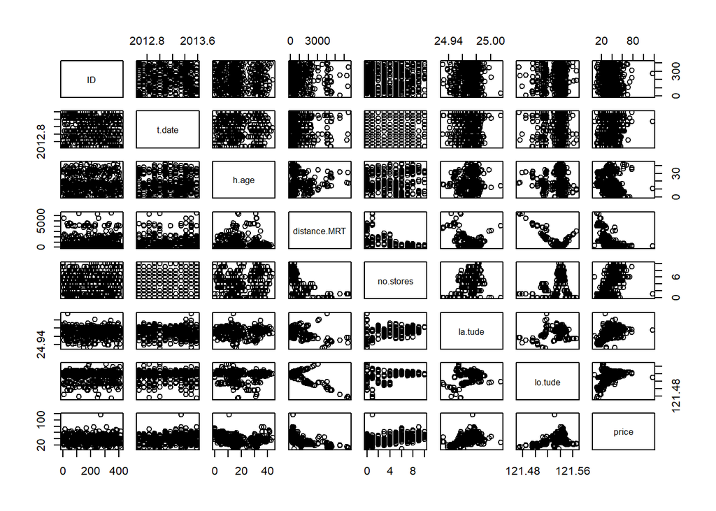

```r
pairs(housing)
```

# Get correlation matrix and round up value for 4 decimal points

```r
round(cor(housing),4)
```

```
##                   ID  t.date   h.age distance.MRT no.stores la.tude lo.tude
## ID            1.0000 -0.0487 -0.0328      -0.0136   -0.0127 -0.0101 -0.0111
## t.date       -0.0487  1.0000  0.0175       0.0609    0.0096  0.0351 -0.0411
## h.age        -0.0328  0.0175  1.0000       0.0256    0.0496  0.0544 -0.0485
## distance.MRT -0.0136  0.0609  0.0256       1.0000   -0.6025 -0.5911 -0.8063
## no.stores    -0.0127  0.0096  0.0496      -0.6025    1.0000  0.4441  0.4491
## la.tude      -0.0101  0.0351  0.0544      -0.5911    0.4441  1.0000  0.4129
## lo.tude      -0.0111 -0.0411 -0.0485      -0.8063    0.4491  0.4129  1.0000
## price        -0.0286  0.0875 -0.2106      -0.6736    0.5710  0.5463  0.5233
##                price
## ID           -0.0286
## t.date        0.0875
## h.age        -0.2106
## distance.MRT -0.6736
## no.stores     0.5710
## la.tude       0.5463
## lo.tude       0.5233
## price         1.0000
```

# Variable selecting using - Adjusted R-squared value

```r
summary(lm(price~t.date, data = housing))$adj.r.squared
```

```
## [1] 0.005246001
```

```r
summary(lm(price~h.age, data = housing))$adj.r.squared
```

```
## [1] 0.04201891
```

```r
summary(lm(price~distance.MRT, data = housing))$adj.r.squared
```

```
## [1] 0.4524284
```

```r
summary(lm(price~no.stores, data = housing))$adj.r.squared
```

```
## [1] 0.3244108
```

```r
summary(lm(price~la.tude, data = housing))$adj.r.squared
```

```
## [1] 0.2967482
```

```r
summary(lm(price~lo.tude, data = housing))$adj.r.squared
```

```
## [1] 0.2720662
```

#0.4524284 is the largerst value, therefore the model: price~distance.MRT

```r
summary(lm(price~distance.MRT+t.date, data = housing))$adj.r.squared
```

```
## [1] 0.4677505
```

```r
summary(lm(price~distance.MRT+h.age, data = housing))$adj.r.squared
```

```
## [1] 0.4886705
```

```r
summary(lm(price~distance.MRT+no.stores, data = housing))$adj.r.squared
```

```
## [1] 0.4941186
```

```r
summary(lm(price~distance.MRT+la.tude, data = housing))$adj.r.squared
```

```
## [1] 0.4849969
```

```r
summary(lm(price~distance.MRT+lo.tude, data = housing))$adj.r.squared
```

```
## [1] 0.4522289
```

#0.4941186 is the largerst value, therefore the model: price ~ distance.MRT + no.stores

```r
summary(lm(price~distance.MRT+no.stores+t.date, data = housing))$adj.r.squared
```

```
## [1] 0.5066518
```

```r
summary(lm(price~distance.MRT+no.stores+h.age, data = housing))$adj.r.squared
```

```
## [1] 0.5377052
```

```r
summary(lm(price~distance.MRT+no.stores+la.tude, data = housing))$adj.r.squared
```

```
## [1] 0.5176695
```

```r
summary(lm(price~distance.MRT+no.stores+lo.tude, data = housing))$adj.r.squared
```

```
## [1] 0.4931943
```

#0.5377052 is the largerst value, therefore the model: price ~ distance.MRT + no.stores + h.age

```r
summary(lm(price~distance.MRT+no.stores+h.age+t.date, data = housing))$adj.r.squared
```

```
## [1] 0.5509482
```

```r
summary(lm(price~distance.MRT+no.stores+h.age+la.tude, data = housing))$adj.r.squared
```

```
## [1] 0.5669409
```

```r
summary(lm(price~distance.MRT+no.stores+h.age+lo.tude, data = housing))$adj.r.squared
```

```
## [1] 0.5372686
```

#0.5669409 is the largerst value, therefore the model: price ~ distance.MRT + no.stores + h.age + la.tude

```r
summary(lm(price~distance.MRT+no.stores+h.age+la.tude+t.date, data = housing))$adj.r.squared
```

```
## [1] 0.5771845
```

```r
summary(lm(price~distance.MRT+no.stores+h.age+la.tude+lo.tude, data = housing))$adj.r.squared
```

```
## [1] 0.5659063
```

#0.5771845 is the largerst value, therefore the model: price ~ distance.MRT + no.stores + h.age + la.tude + t.date

```r
summary(lm(price~distance.MRT+no.stores+h.age+la.tude+t.date+lo.tude, data = housing))$adj.r.squared
```

```
## [1] 0.5762137
```

# Plot adjusted R-squared values

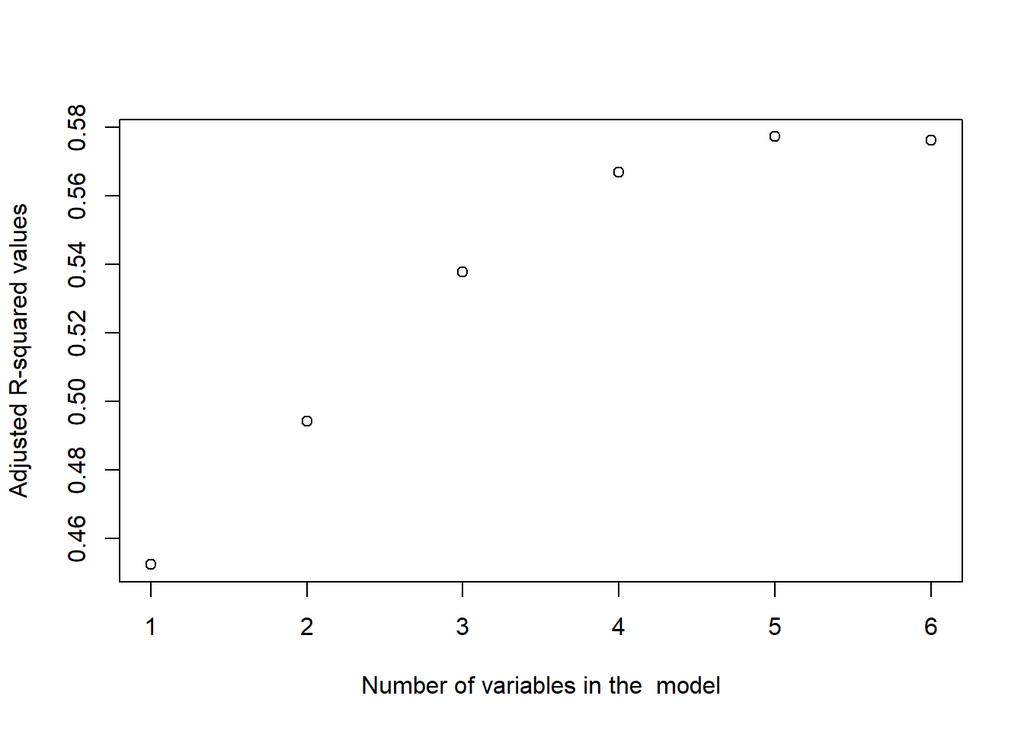

```r
plot(c(seq(from=1,to=6)),c(0.4524284,0.4941186,0.5377052, 0.5669409,0.5771845,0.5762137),
  xlab= "Number of variables in the  model",
  ylab= "Adjusted R-squared values")
```

#According to the plot there is no significant increase between 5th and 6th variable #Therefore 6th variable should not include in the model #Therefore the model is, # price ~ price~distance.MRT+no.stores+h.age+la.tude+t.date

```r
lm_model = lm(price~distance.MRT+no.stores+h.age+la.tude+t.date,data = housing)
summary(lm_model)
```

```
##
## Call:
## lm(formula = price ~ distance.MRT + no.stores + h.age + la.tude +
##     t.date, data = housing)
##
## Residuals:
##     Min      1Q  Median      3Q     Max
## -35.623  -5.371  -1.020   4.244  75.346
##
## Coefficients:
##                Estimate Std. Error t value Pr(>|t|)
## (Intercept)  -1.596e+04  3.233e+03  -4.936 1.17e-06 ***
## distance.MRT -4.353e-03  4.899e-04  -8.887  < 2e-16 ***
## no.stores     1.136e+00  1.876e-01   6.056 3.17e-09 ***
## h.age        -2.694e-01  3.847e-02  -7.003 1.04e-11 ***
## la.tude       2.269e+02  4.417e+01   5.136 4.36e-07 ***
## t.date        5.135e+00  1.555e+00   3.303  0.00104 **
## ---
## Signif. codes:  0 '***' 0.001 '**' 0.01 '*' 0.05 '.' 0.1 ' ' 1
##
## Residual standard error: 8.848 on 408 degrees of freedom
## Multiple R-squared:  0.5823, Adjusted R-squared:  0.5772
## F-statistic: 113.8 on 5 and 408 DF,  p-value: < 2.2e-16
```

#R^2 = 58.23%, Approximately 58.23% of variability in house price can be explained by this model

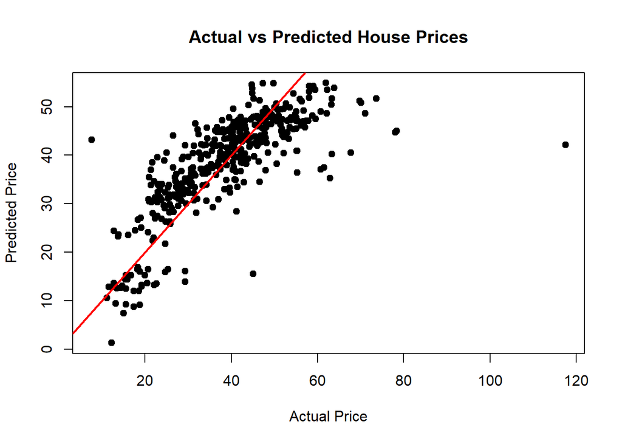

```r
predicted = predict(lm_model)
housing$predicted = predict(lm_model)
plot(housing$price, predicted,
     xlab = "Actual Price",
     ylab = "Predicted Price",
     main = "Actual vs Predicted House Prices",
     pch = 19)

abline(a = 0, b = 1, col = "red", lwd = 2)
```

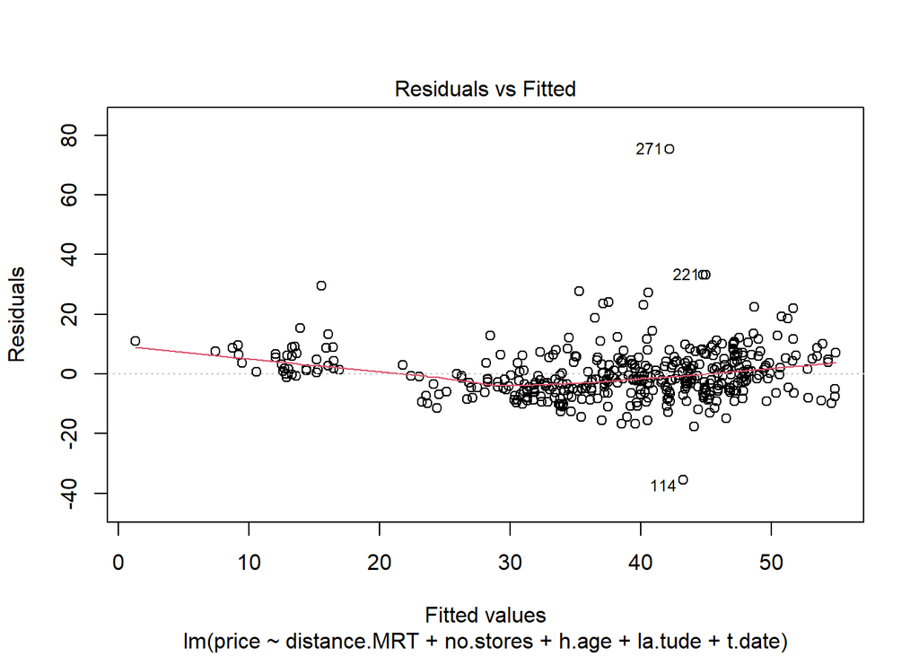

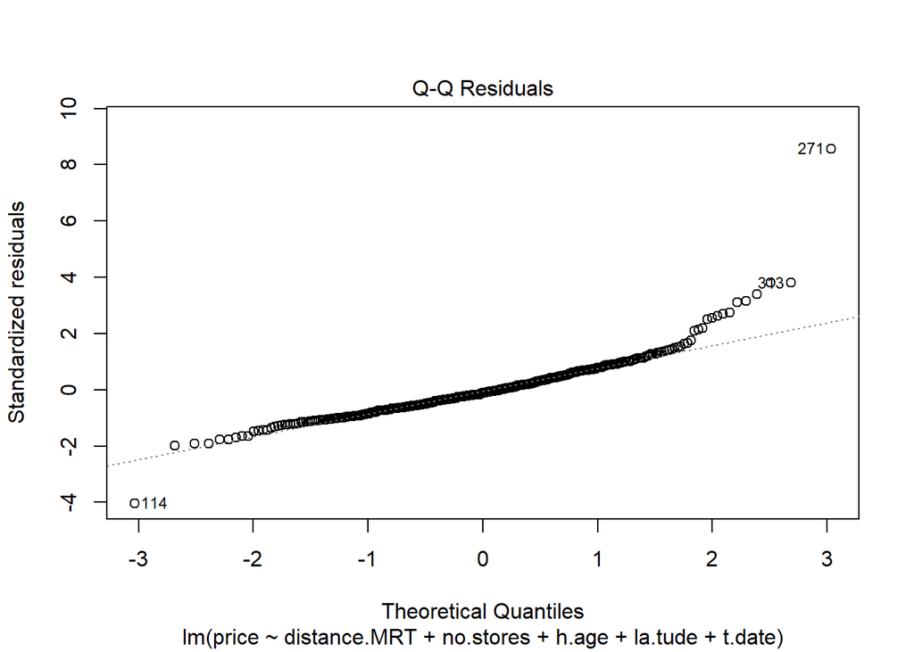

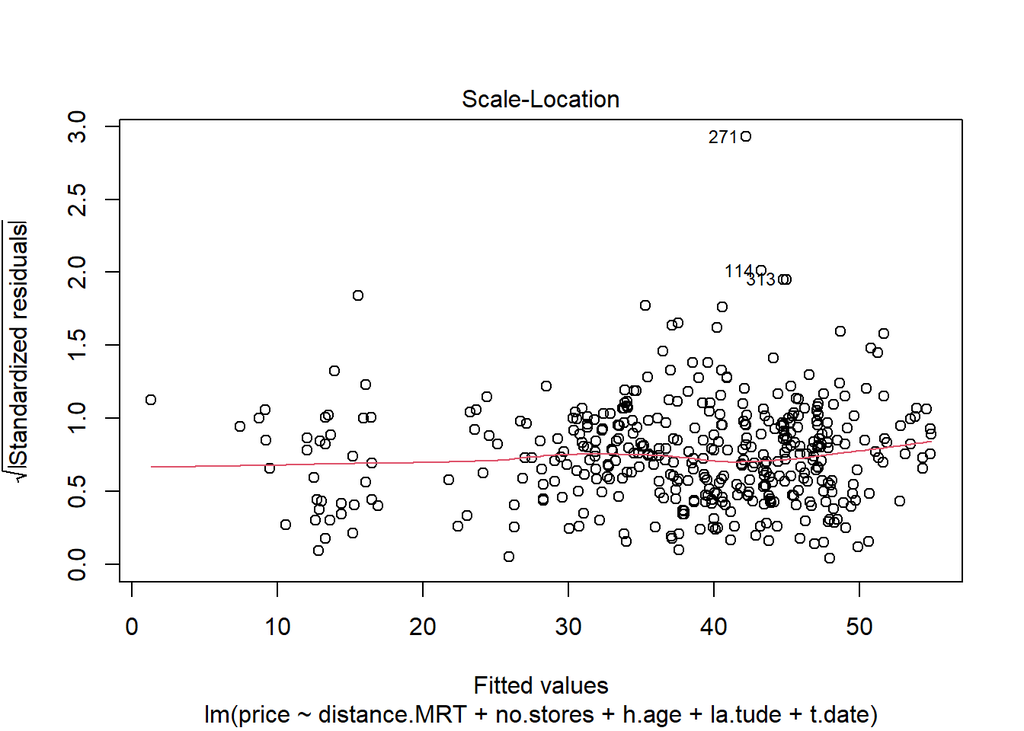

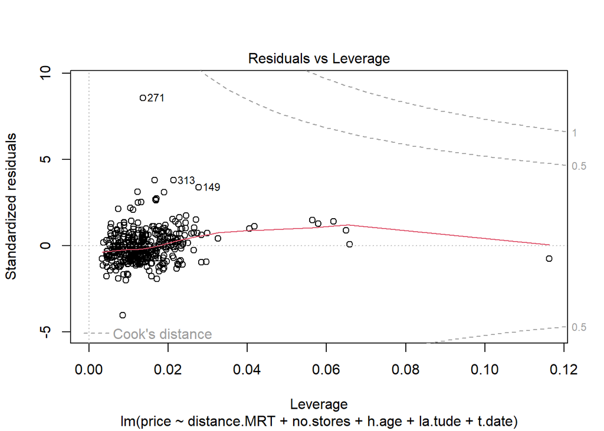

```r
plot(lm_model)
```

# Check for normality of residuals

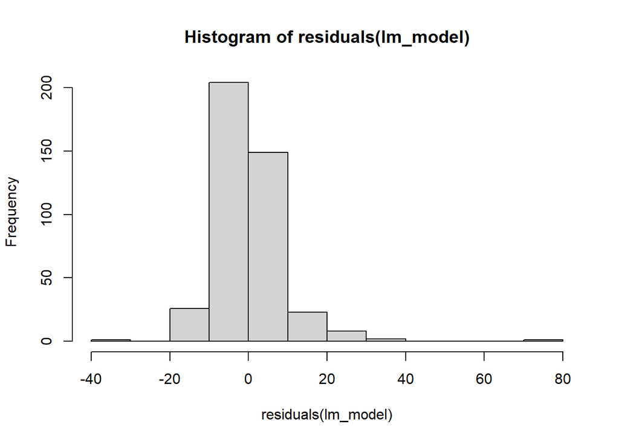

```r
hist(residuals(lm_model))
```

```r
shapiro.test(residuals(lm_model))
```

```
##
##  Shapiro-Wilk normality test
##
## data:  residuals(lm_model)
## W = 0.8755, p-value < 2.2e-16
```

#The small p-value(< 2.2e-16) indicates that,we can reject the null hypothesis; #Residuals are not normally distributed

# Check for multicollinearity

```r
library(car)
round(vif(lm_model),3)
```

```
## distance.MRT    no.stores        h.age      la.tude       t.date
##        2.017        1.611        1.013        1.586        1.014
```

#Since all VIF values are below 5 , indicating no evidence of problematic multicollinearity among the predictor variable

# Check for homoscedasticity

```r
#install.packages("lmtest")
library(lmtest)
bptest(lm_model)
```

```
##
##  studentized Breusch-Pagan test
##
## data:  lm_model
## BP = 5.7624, df = 5, p-value = 0.33
```

#p = 0.33 > 0.05 (High p-value): Fail to reject H₀; assume homoscedasticity good for standard regression

# Check for outliers

#View the Cook’s Distance plot

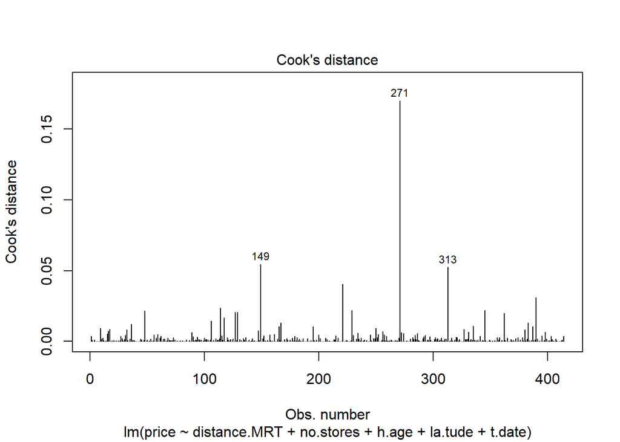

```r
plot(lm_model, which = 4)
```

# Rows 149, 271 and 313 are outliers

# Confidence interval

```r
confint(lm_model)
```

```
##                      2.5 %        97.5 %
## (Intercept)  -2.231556e+04 -9.602961e+03
## distance.MRT -5.316347e-03 -3.390353e-03
## no.stores     7.673319e-01  1.504955e+00
## h.age        -3.449970e-01 -1.937617e-01
## la.tude       1.400440e+02  3.137192e+02
## t.date        2.078661e+00  8.190889e+00
```